# HW4_syQiu

```r
# | echo: false
# | message: false
library(tidyverse)
library(ggplot2)
library(dplyr)
# Themes set
theme_set(theme_light(base_family = "Avenir Next Condensed"))
```

# 4.1 Exercise

```r
x <- rnorm(100000, mean = 0, sd = 1)
mean(x >= -1 & x <= 1)
```

```
[1] 0.68153
```

```r
mean(x >= -2 & x <= 2)
```

```
[1] 0.95503
```

```r
mean(x >= 0)
```

```
[1] 0.49807
```

```r
mean(x <= 0)
```

```
[1] 0.50193
```

# 4.2 Exercise

```r
quantile(x)
```

```
          0%          25%          50%          75%         100%
-5.008952616 -0.681968004 -0.004511117  0.676224904  4.314227240
```

# 4.3 Exercise

```r
quantile(x, prob = c(0.005, 0.995))
```

```
     0.5%     99.5%
-2.558280  2.549484
```

# 4.4 Exercise

```r
mean(x >= -2.576 & x <= 2.576)
```

```
[1] 0.99058
```

# 4.5 Exercise

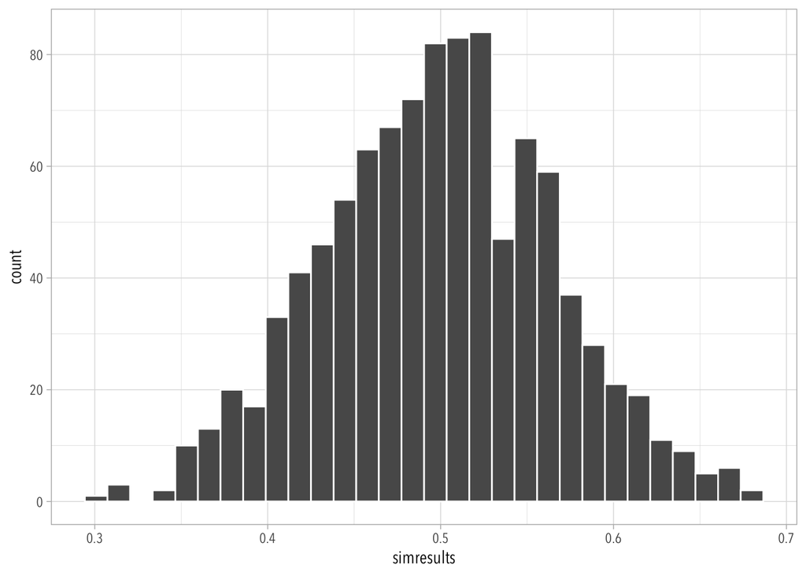

```r
df <- tibble(sid = c(1:1000)) |>
  rowwise() |>
  mutate(simresults = sum(runif(n = 20, min = 0, max = 1))/20)

ggplot(df, aes(x = simresults)) +
  geom_histogram(color = "white")
```

```r
sd(df$simresults)
```

```
[1] 0.06580111
```

```r
sd(runif(n = 20, min = 0, max = 1))/sqrt(20)
```

```
[1] 0.05630259
```

The standard deviation of the sampling distribution is not so close to the standard error…If we increase the sample size (e.g. to 1000), it will be very close:

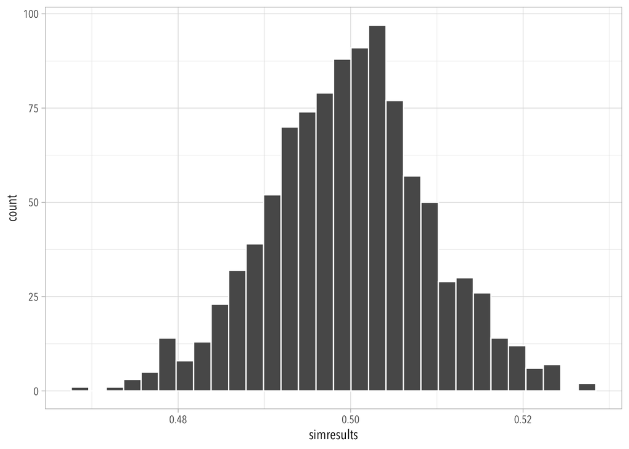

```r
df <- tibble(sid = c(1:1000)) |>
  rowwise() |>
  mutate(simresults = sum(runif(n = 1000, min = 0, max = 1))/1000)

ggplot(df, aes(x = simresults)) +
  geom_histogram(color = "white")
```

```r
sd(df$simresults)
```

```
[1] 0.009328431
```

```r
sd(runif(n = 1000, min = 0, max = 1))/sqrt(1000)
```

```
[1] 0.009165703
```

# 4.6 Exercise

It means when the sample size >= 30, the sample size is large enough for its sample means to be considered as a normal distribution.

Steve’s example:

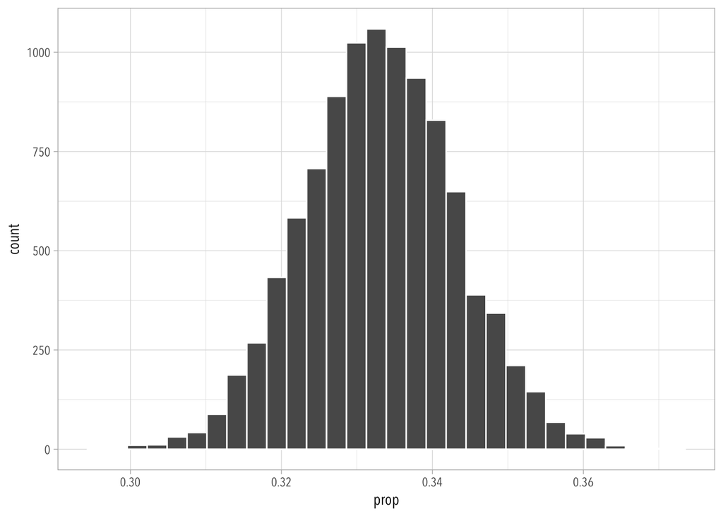

```r
set.seed(123)
est_prop <- 1/3
num_sims <- 10000
svy_size <- 2247

sims <- tibble(sim_num = 1:num_sims) |>
  uncount(svy_size)

sims <- sims |>
  mutate(conservative = rbinom(num_sims*svy_size, 1, est_prop)) |>
  group_by(sim_num) |>
  summarize(prop = mean(conservative))

ggplot(sims,aes(x = prop)) +
  geom_histogram(color = "white")
```

```r
std_error <- sqrt((1/3)*(2/3))/sqrt(svy_size)
ci95_cmpt <- c(est_prop - 1.96 * std_error, est_prop + 1.96 * std_error)
ci95 <- c(quantile(sims$prop, 0.025), quantile(sims$prop, 0.975))
ci95_cmpt
```

```
[1] 0.3138417 0.3528250
```

```r
ci95
```

```
     2.5%     97.5%
0.3137517 0.3529150
```

If we repeat the simulation with `svy_size` equals to 10, 20, 30, 50, 100, 1000, 3000, 5000

```r
set.seed(123)
est_prop <- 1/3
num_sims <- 10000
svy_size_vector <- c(10, 20, 30, 50, 100, 1000, 3000, 5000)

for (svy_size in svy_size_vector){
  sims <- tibble(sim_num = 1:num_sims) |>
    uncount(svy_size)

  sims <- sims |>
    mutate(conservative = rbinom(num_sims*svy_size, 1, est_prop)) |>
    group_by(sim_num) |>
    summarize(prop = mean(conservative))

  std_error <- sqrt((1/3)*(2/3))/sqrt(svy_size)
  ci95_cmpt <- c(est_prop - 1.96 * std_error, est_prop + 1.96 * std_error)
  ci95 <- c(quantile(sims$prop, 0.025), quantile(sims$prop, 0.975))
  print(list(svy_size, ci95_cmpt, ci95))
}
```

```
[[1]]
[1] 10

[[2]]
[1] 0.04115378 0.62551288

[[3]]
 2.5% 97.5%
  0.1   0.6

[[1]]
[1] 20

[[2]]
[1] 0.1267312 0.5399355

[[3]]
 2.5% 97.5%
 0.15  0.55

[[1]]
[1] 30

[[2]]
[1] 0.1646434 0.5020233

[[3]]
     2.5%     97.5%
0.1666667 0.5000000

[[1]]
[1] 50

[[2]]
[1] 0.2026667 0.4640000

[[3]]
 2.5% 97.5%
 0.20  0.46

```

[output cut: 24 more lines]

```
[1] 0.3164643 0.3502023

[[3]]
     2.5%     97.5%
0.3163333 0.3500000

[[1]]
[1] 5000

[[2]]
[1] 0.3202667 0.3464000

[[3]]
  2.5%  97.5%
0.3200 0.3464
```

No. When the sample size is lower than 30, the 95% confidence interval is not about 2 standard errors away from 0.33. However, when the sample size increases, it is more and more close to 2 standard errors away from 0.33. The results are consistent with my initial interpretation of the idea about sample size and CLT.